# Social Data Science - Twitter network data

David Garcia, 2021

In this tutorial we will learn how to retrieve different kinds of network data from Twitter and how to process them in R.

### Follower links

One of the most interesting networks in Twitter is the follower network, in which nodes are users and links connect user $u$ with user $v$ if $u$ follows $v$. The rtweet package allows you to get the list of followers of a user with the get_followers() function:

```r
library(rtweet)
followers <- get_followers("dgarcia_eu")
head(followers)
```

```
## # A tibble: 6 × 2
##   from_id             to_id
##   <chr>               <chr>
## 1 1322344303939694594 dgarcia_eu
## 2 735846007896870912  dgarcia_eu
## 3 46191256            dgarcia_eu
## 4 1139059532          dgarcia_eu
## 5 1435562106296971267 dgarcia_eu
## 6 1435877860972113920 dgarcia_eu
```

Sometimes you are interested on retrieving the links in the direction they follow, which would be by getting the list of accounts followed by certain one. In the Twitter API, the people followed by a user are called the “friends” of that uses, so the get_friends() function gives you that list:

```r
followings <- get_friends("dgarcia_eu")
head(followings)
```

```
## # A tibble: 6 × 2
##   from_id    to_id
##   <chr>      <chr>
## 1 dgarcia_eu 25572108
## 2 dgarcia_eu 795885295
## 3 dgarcia_eu 95226101
## 4 dgarcia_eu 2835152008
## 5 dgarcia_eu 1553813312873398278
## 6 dgarcia_eu 277233913
```

Getting friends has also a low rate limit as in the case of followers, but at least these limits are parallel so you can request both at the same time.

The list of people we follow can tell a lot about ourselves in a similar way as [likes on Facebook reveal private attributes](https://www.pnas.org/content/110/15/5802). For example, the work of Pablo Barberá shows that following lists are useful to calculate [a score of political orientation in the US](https://journals.sagepub.com/doi/abs/10.1177/0956797615594620).

### Reply networks

First, we retrieve the basic profile information of the users of a Twitter list. Here we are using the list of professor and department accounts of ETH Zurich (https://twitter.com/i/lists/984765033673646080). The function list_members retrieves the user ids in the list and the profile objects for each user:

```r
library(dplyr)
users <- lists_members(list_id = 984765033673646080)
head(users)
```

```
## # A tibble: 6 × 40
##   user_id    name  scree…¹ locat…² descr…³ url   prote…⁴ follo…⁵ frien…⁶ liste…⁷
##   <chr>      <chr> <chr>   <chr>   <chr>   <chr> <lgl>     <int>   <int>   <int>
## 1 147908096… Günt… G_Diss… ""      Resear… <NA>  FALSE      1500     211       6
## 2 141096283… Zamb… zambon… ""      That's… <NA>  FALSE        68       0       2
## 3 139145009… Bild… ETHBil… "Züric… Wissen… http… FALSE       847    1064      10
## 4 136966650… ETH … ethwoh… "Zuric… Resear… http… FALSE       108     330       3
## 5 135624740… ETH … ETHSPH  ""      Join t… http… FALSE       433     174       5
## 6 132315902… Seis… SWP_ET… "Zuric… Twitte… http… FALSE       698      20      11
## # … with 30 more variables: created_at <dttm>, favourites_count <int>,
## #   utc_offset <lgl>, time_zone <lgl>, geo_enabled <lgl>, verified <lgl>,
## #   statuses_count <int>, lang <lgl>, contributors_enabled <lgl>,
## #   is_translator <lgl>, is_translation_enabled <lgl>,
## #   profile_background_color <chr>, profile_background_image_url <chr>,
## #   profile_background_image_url_https <chr>, profile_background_tile <lgl>,
## #   profile_image_url <chr>, profile_image_url_https <chr>, …
```

```r
nrow(users)
```

```
## [1] 254
```

We are going to focus on a random sample of 100 and retrieve their latest 100 tweets with the get_timelines() function:

```r
user_expansions()
```

```
## [1] "pinned_tweet_id"
```

```r
tweet_expansions()
```

```
## [1] "author_id"                      "in_reply_to_user_id"
## [3] "geo.place_id"                   "entities.mentions.username"
## [5] "edit_history_tweet_ids"         "attachments.media_keys"
## [7] "attachments.poll_ids"           "referenced_tweets.id"
## [9] "referenced_tweets.id.author_id"
```

```r
userids <- sample(users$user_id, 100)
tweets <- get_timelines(userids, n=100)
userdf <- users_data(tweets)
tweets$user_id <- userdf$id_str
head(tweets)
```

```
## # A tibble: 6 × 44
##   created_at               id id_str   text  full_…¹ trunc…² entities     source
##   <dttm>                <dbl> <chr>    <chr> <chr>   <lgl>   <list>       <chr>
## 1 2023-02-10 00:22:02 1.62e18 1623824… "RT … "RT @m… FALSE   <named list> "<a h…
## 2 2023-02-10 00:21:16 1.62e18 1623824… "RT … "RT @I… FALSE   <named list> "<a h…
## 3 2023-02-07 16:13:58 1.62e18 1622976… "Gau… "Gauch… FALSE   <named list> "<a h…
## 4 2023-02-03 15:13:31 1.62e18 1621512… "RT … "RT @e… FALSE   <named list> "<a h…
## 5 2023-02-03 07:35:40 1.62e18 1621396… "RT … "RT @A… FALSE   <named list> "<a h…
## 6 2023-01-24 21:58:38 1.62e18 1617990… "RT … "RT @F… FALSE   <named list> "<a h…
## # … with 36 more variables: in_reply_to_status_id <dbl>,
## #   in_reply_to_status_id_str <chr>, in_reply_to_user_id <dbl>,
## #   in_reply_to_user_id_str <chr>, in_reply_to_screen_name <chr>, geo <list>,
## #   coordinates <list>, place <list>, contributors <lgl>,
## #   is_quote_status <lgl>, retweet_count <int>, favorite_count <int>,
## #   favorited <lgl>, favorited_by <lgl>, retweeted <lgl>, scopes <lgl>,
## #   lang <chr>, possibly_sensitive <list>, display_text_width <lgl>, …
```

```
## ℹ Users data at users_data()
```

Accessing timelines in Twitter has a much higher limit of 900 requests per 15-minute window. This way you can get at most 3200 tweets per user and you have another limit of at most [100000 calls per 24-hour period.](https://developer.twitter.com/en/docs/twitter-api/v1/tweets/timelines/api-reference/get-statuses-user_timeline)

Tweets that are replies will generate rows in the result with the reply_to_user_id column set to the numeric id of the user being replied to:

```r
head(tweets$in_reply_to_user_id_str, n=20)
```

```
##  [1] NA                    NA                    NA
##  [4] NA                    NA                    NA
##  [7] NA                    NA                    NA
## [10] NA                    NA                    NA
## [13] NA                    "941700582942928896"  "1162396739913039874"
## [16] NA                    NA                    NA
## [19] "1017910602021457921" NA
```

We can extract all reply links in our data by taking this information and filtering for users in our sample:

```r
tweets %>%
  select(user_id, in_reply_to_user_id_str) %>%
  filter(!is.na(in_reply_to_user_id_str)) %>%
  inner_join(data.frame(user_id=userids)) %>%
  inner_join(data.frame(in_reply_to_user_id_str=userids)) -> repliesdf
dim(repliesdf)
```

```
## [1] 446   2
```

And construct the edges by counting reply instances as their weight:

```r
names(repliesdf) <- c("from", "to")
repliesdf %>%
  group_by(to, from) %>%
  summarize(weight = n()) -> edgesdf
```

[output not shown]

```r
head(edgesdf)
```

```
## # A tibble: 6 × 3
## # Groups:   to [6]
##   to                  from                weight
##   <chr>               <chr>                <int>
## 1 1021257220741369856 1021257220741369856      4
## 2 1044052956918644737 1044052956918644737      1
## 3 1047807847738888192 1047807847738888192      1
## 4 1109420900653416449 1109420900653416449      3
## 5 1151750963423825922 1151750963423825922      2
## 6 1180141487142707201 1180141487142707201      4
```

We can then create the graph and plot it:

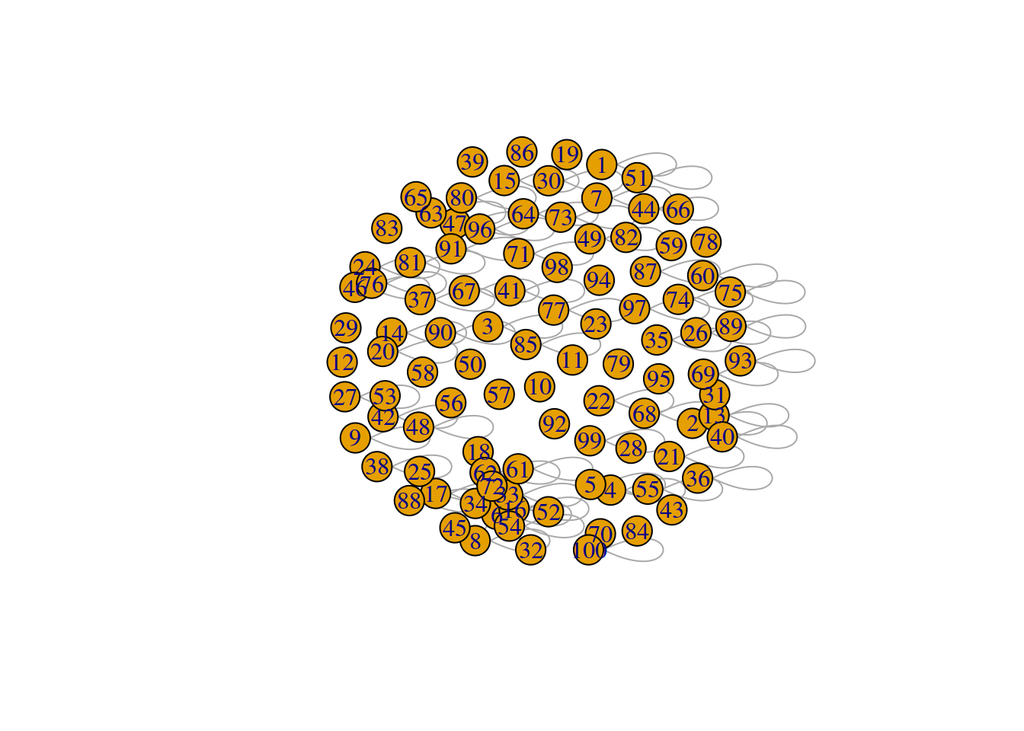

```r
library(tidygraph)
graph<-tbl_graph(data.frame(id=userids),edgesdf, directed=F, node_key = "id")
plot(graph)
```

If you see many self-loops, that might be due to accounts building threads of replies.

### Retweet networks

```r
retweeted_users <- NULL
for (tweet in tweets$retweeted_status)
{
  if (!is.na(tweet))
  {
    retweeted_users <- c(retweeted_users, tweet$user$id_str)
  }
  else
  {
    retweeted_users <- c(retweeted_users, NA)
  }
}
```

[output not shown]

[output not shown]

```r
tweets$retweeted_user <- retweeted_users

tweets %>%
  select(user_id, retweeted_user) %>%
  filter(!is.na(retweeted_user)) %>%
  inner_join(data.frame(user_id=userids)) %>%
  inner_join(data.frame(retweeted_user=userids)) -> retweetsdf
dim(retweetsdf)
```

```
## [1] 274   2
```

We then construct edges. The directionality of retween networks can be decided in both ways, either from retweeted to retweeted as an information flow network or from retweeter to retweeted as a “giving credit” or endorsement network. We choose this last option to resemple the follower networks:

```r
names(retweetsdf) <- c("from", "to")
retweetsdf %>%
  group_by(to, from) %>%
  summarize(weight = n()) -> edgesdf
```

[output not shown]

```r
head(edgesdf)
```

```
## # A tibble: 6 × 3
## # Groups:   to [5]
##   to                  from                weight
##   <chr>               <chr>                <int>
## 1 1044052956918644737 920687490                3
## 2 1047808609210589184 1047808609210589184      3
## 3 1109420900653416449 1263749269766496256      1
## 4 1180141487142707201 2817025603               2
## 5 1187831056487108608 1187831056487108608      1
## 6 1187831056487108608 632671915                3
```

And then we can plot as we did with the replies network:

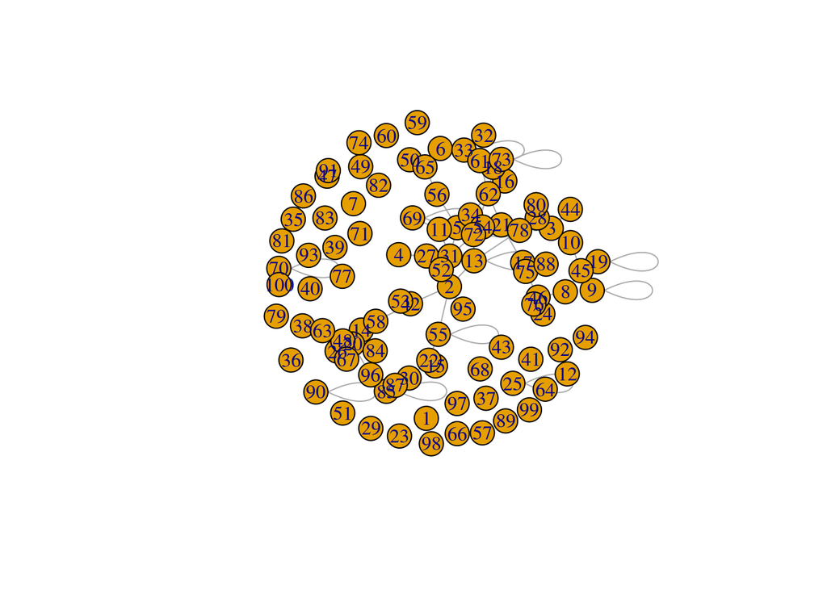

```r
graph<-tbl_graph(data.frame(id=userids),edgesdf, directed=F, node_key = "id")
plot(graph)
```

You might notice quite some differences here, for example there are less self-loops. Users are less likely to retweet themselves than reply to themselves on Twitter.

### Likes information

Twitter allows you to get some data on the likes given by a user to tweets with the get_favorites() function:

```r
likes <- get_favorites("dgarcia_eu", n = 2000)
head(likes)
```

```
## # A tibble: 6 × 43
##   created_at               id id_str   text  full_…¹ trunc…² entities     source
##   <dttm>                <dbl> <chr>    <chr> <chr>   <lgl>   <list>       <chr>
## 1 2023-02-15 16:56:05 1.63e18 1625886… "👋A… "👋As … FALSE   <named list> "<a h…
## 2 2023-02-14 09:42:04 1.63e18 1625415… "Our… "Our n… FALSE   <named list> "<a h…
## 3 2023-02-13 13:08:41 1.63e18 1625104… "A b… "A bea… FALSE   <named list> "<a h…
## 4 2023-02-12 14:56:15 1.62e18 1624769… "\"P… "\"Pse… FALSE   <named list> "<a h…
## 5 2023-02-12 14:56:14 1.62e18 1624769… "I a… "I am … FALSE   <named list> "<a h…
## 6 2023-02-09 10:17:42 1.62e18 1623612… "Nic… "Nice … FALSE   <named list> "<a h…
## # … with 35 more variables: in_reply_to_status_id <dbl>,
## #   in_reply_to_status_id_str <chr>, in_reply_to_user_id <dbl>,
## #   in_reply_to_user_id_str <chr>, in_reply_to_screen_name <chr>, geo <list>,
## #   coordinates <list>, place <list>, contributors <lgl>,
## #   is_quote_status <lgl>, retweet_count <int>, favorite_count <int>,
## #   favorited <lgl>, favorited_by <chr>, retweeted <lgl>, scopes <lgl>,
## #   lang <chr>, possibly_sensitive <lgl>, display_text_width <lgl>, …
```

```
## ℹ Users data at users_data()
```

The result is a dataframe with the latest tweets liked by the user. A request this way gives you the latest 200 likes, thus the above code can take up to 10 requests. The rate limit for this is 75 requests per 15-min window, so building the likes network for the above list of Twitter users would take a while. The naming of “favorites” instead of likes comes from the earlier desgin of Twitter, where likes did not exist and users could favorite tweets with a star symbol. Now it’s a heart and since the change to likes, it is used much more frequently.

### To learn more

- Get the whole follower list overnight for a set of accounts and plot the resulting network
- With the resulting data, you can measure the overlap in followers between two users as the [Jaccard coefficient](https://en.wikipedia.org/wiki/Jaccard_index). This gives you an undirected, weighted network of follower similarity that you can also plot.
- Build reply and retweet network for the example above but getting all tweets up to the 3200-tweet limit. Is it different from the one plotted based on a sample?
- Based on the latest tweets of a user, you can calculate the T-index of the user as the maximum number T such that the user has posted T tweets with at least T likes (similar to the h-index for scientists). Which account from ETH has the highest T-index?